Olá! Antes de tudo, preciso comparar o lucro com as outras coisas vou avaliar inicialmente o lucro em relacao a genero, país e nota.

[figure not shown]

Grafico 1. Nota no imdb e Lucro.

Com esse grafico posso avaliar de antemão que nota alta (acima de 8) não é pre requisito de lucro, inclusive alguns filmes tiveram prejuízo mesmo com nota alta. vou deixar o parametro nota um pouco de lado por enquanto. Talvez não volte.

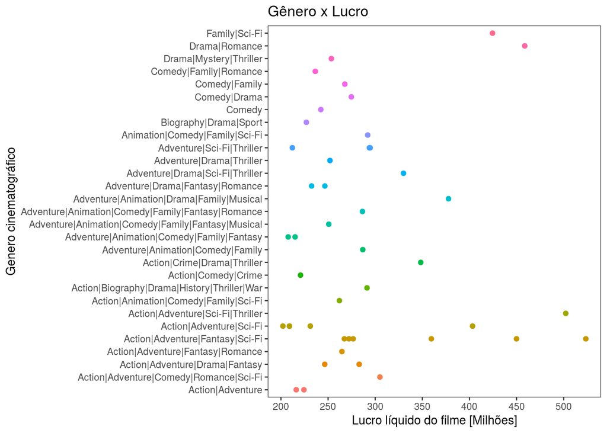

Grafico 2. Gênero de filme e Lucro.

Bem, generos como **sci-fi, ação, aventura, fantasia, animação, comédia**, aparecem frequentes nas classificações mais rentáveis. Não por acaso, muitos desses são gêneros que demandam muito investimento na produção com cenários, computação grafica e quaisquer outros recursos que requeiram a criação de mundos e realidades alternativas. O ideal aqui seria dividir as colunas, então para diminuir o ruído das classificações a estrategia foi aplicar um filtro no lucro. Dei uma filtrada pra superior a 200 Mi.

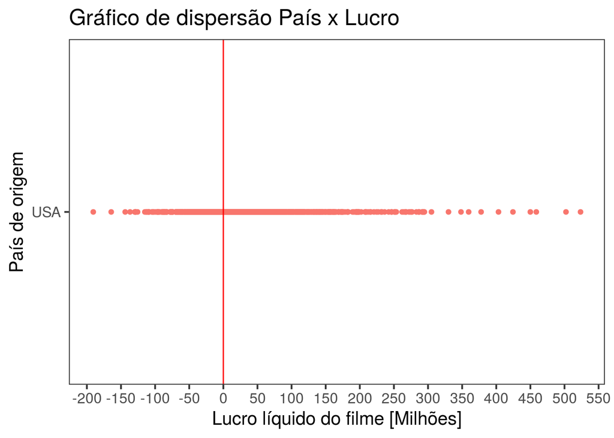

Grafico 3.País e Lucro.

Pelo visto vcs vao ter que ir pros eua ehin.. Mas não sei o que tem lá que possa ser emulado fora, e renda tanto quanto um filme de lá. ta meio desatualizada essa lista, cadê parasita que é sul coreano?

vamos investigar os diretores associados agora:

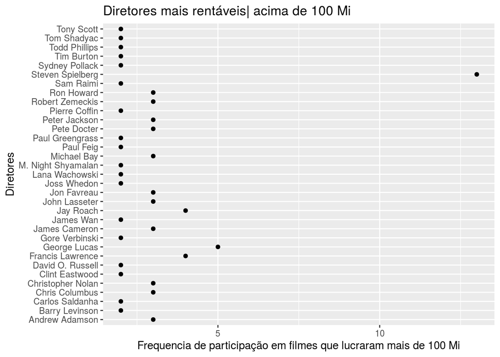

Grafico 4. Diretores e Lucro.

Eu pedi diretores que lucraram acima de 100mi mais de 1 vez, pq uma vez pode ter sido sorte. podemos ver que certamente vcs deveriam apostar no Spielperg, ou no George lucas.. o que particularmente acho seguro, mas extremamente cansativo. Ngm aguenta mais eles né? Talvez seja interessante procurar diretores que não tenham superado tanto 100mi mas lucram com maior frequencia nesse caso vcs colocam mais o pé na realidade, apostam sem precisar gastar tanto com diretores inacessíveis (e talvez dificeis de lidar.

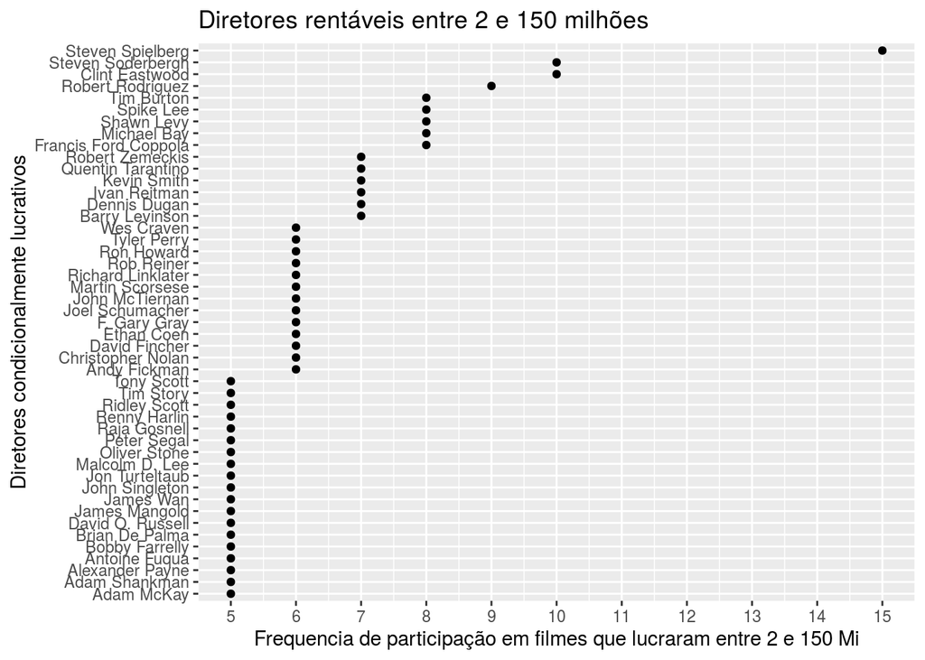

Grafico 5. Diretores e Lucro.

Spielberg ta me atrapalhando, vou chutar ele da analise. Ps.: eu percebi que ele foi o maior da serie e seria uma excelente aposta.. mas o ranço quando vem

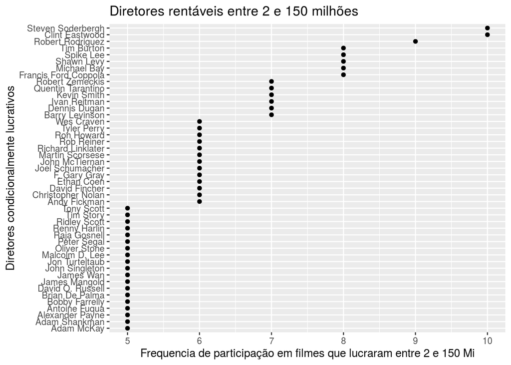

Grafico 6. Diretores e Lucro sem o spielberg.

Que ótimo! gosto muito do clint eastwood, já steven soderbergh e robert rodriguez nao sei quem são. Até o fim da pagina, já vou ter pesquisado.Mas parece uma boa. outras opções são Spike lee, Tim burton, Michael Bay, Coppola, Shawn Levy. Se não me engano o shawn está muito vinculado ao estilo ação&aventura + comédia.

Vamos fazer uma analise parecida, mas com os atores agora. Lembrando que tem ator que não se dá bem com certos diretores ehin.. tem q ver isso.

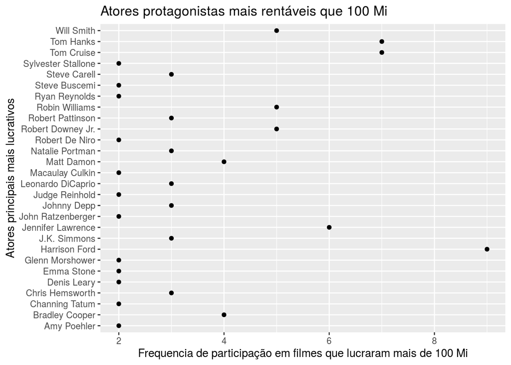

Grafico 7. Atores principais e Lucro.

Aparentemente o Harrison ford é o cara. Mas vamos lembrar que ele fez Star Wars E Indiana Jones várias vezes, ambas as franquias dirigidas pelo George Lucas. A menos que vcs queiram fazer um enésimo Star Wars, com o ator mais top da parada e o diretor mais top da parada, e que trabalharam muito juntos. Se dão bem, claro.. mas será q o publico não ta meio cansado?

As proximas opções são Tom hanks, Tom cruise, Jennifer Lawrence. a Jennifer tem 30 anos, os Tom’s têm idade que regula ali pelos 60 anos. Pelo grafico, com 30 anos ela fez parte de produções que renderam mais de 100 mi, quase tantas vezes quanto os Tom’s que teem o dobro da idade dela.. certamente ela é uma aposta acertada. Mas como ninguem faz nada sozinho.. poxa o Tom hanks é mó gente fina. Tom cruise é um mané excentrico associado a escandalos de violência e abuso, já descarto. Sinto ótimas vibrações numa quimica de cena do Tom e a Jennifer. Não como casal, claro. Mas qualquer outra coisa.

Vamos ver os atores que rendem bem, mas nao necessariamente acima de 100 Milhões.

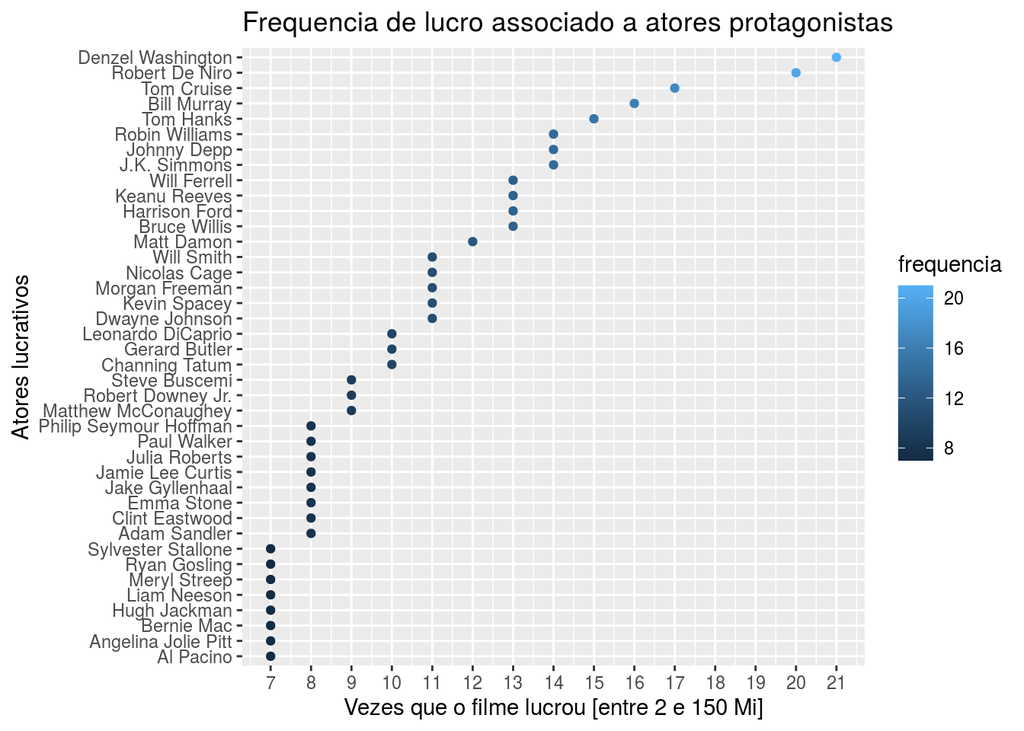

Grafico 8. atores principais e Lucro.

Denzel e Robert de niro são caras muito bons mesmo. Olha o Tom hanks ali de novo.. pelo visto além de estar associado aos filmes que lucraram mais de 100 Mi, também está associado aos filmes que lucraram bastante mas não tanto. Além de ser muito gente fina mesmo.

Até interrompeu sua corrida no central park pra parabenizar um casal que fazia ensaio de casamento.. olha:

[figure not shown]

Tom hanks invadindo ensaio do casal. Fonte: reprodução Extra

[figure not shown]

Tom hanks invadindo ensaio do casal. Fonte: instagram do Tom Hanks

É ou não é um sujeito muito daora? Bom, Já ia me esquecendo dos atores considerados menos estrelinhas:

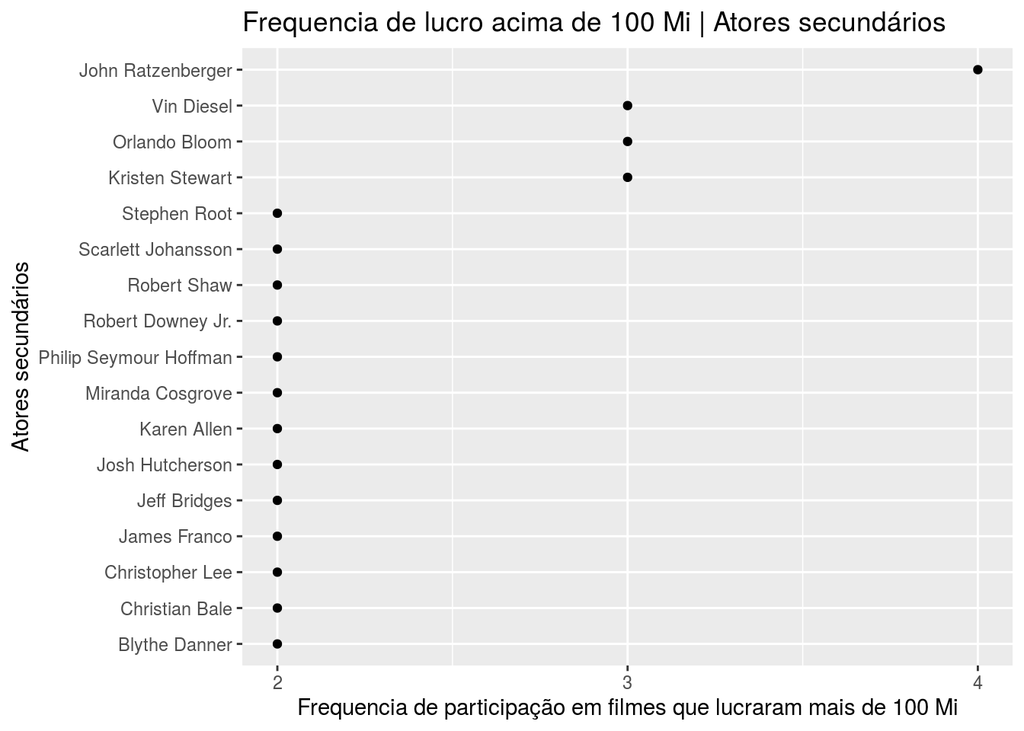

Grafico 9. Atores secundários e Lucro.

Como assim.. quem é esse john ratzenberger? deixa que eu conto.. procurei no google.

**É um ator dublador!!** Fez varias vozes legais, Toy Story, Carros Monstros SA, Vida de Inseto, Os Incriveis, Wall-e, Up, Procurando nemo.. Vai uma produção de animação aí?

[figure not shown]

Agora só pra terminar:

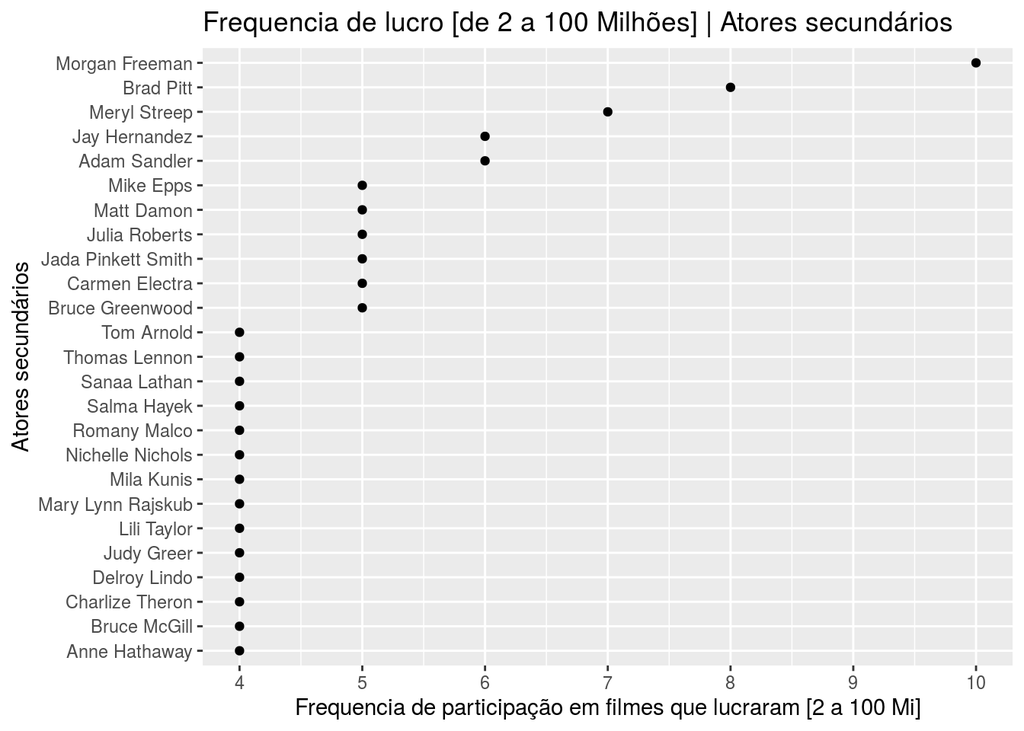

Grafico 10. Atores secundários e Lucro.

Parece que o Morgan Freeman, Brad Pitt e Meryl Streep tem facilidade nessa modalidade de lucro não tão alto, mas com frequência. Achei estranho o Morgan e a Meryl estarem na coluna de secundários, ou não tão importantes. Mas ok.

Avaliando todo o conjunto de gráficos, apostaria num filme com a Jennifer Lawrence, Tom Hanks e Meryl streep.  
Dirigidos pelo spielberg ou o george lucas que são muito conhecidos principalmente pelos generos Aventura/Fantasia/Sci-fi.

Uma segunda opção pra sair do mais do mesmo dos diretores estrelinhas demais, seria um dirigido pelo Steven Soderbergh que sabe idealizar esquemas inteligentes e que prendem o espectador. Tem habilidade com o gênero de Ação, e encaixa perfeitamente o humor na medida correta.  
É isso gente, espero ter ajudado nessa difícil decisão.